# Opportunity Insights

```
Last Update: 25-06-16
Author: Heeyoung Lee
```

하버드 경제학과의 Chetty 교수 연구팀은 Opportunity Insights 프로젝트로 유명하다. 이 프로젝트는 미국 내 계층이동과 관련된 다양한 연구들을 세련되지만 직관적인 방법론으로 수행해왔다. 그리고 아주 고맙게도 모든 데이터와 분석 코드를 홈페이지에서 배포한다. ([여기](https://opportunityinsights.org/paper-category/neighborhoods/))

## 계층이동 연구 모듈 1

아마 가장 많은 주목을 받은 2016년 연구 (모듈 1)는 1978-1983년생(현재 40대 초반) 약 2,050만 명을 대상으로 그들이 30대 중반에 도달했을 때의 평균적인 성과를 측정한다. 이들을 23세까지 거주했던 지역으로 추적하여, 미국 전역 7만 개 센서스 트랙트(평균 4,200명 거주), 카운티, 통근권역별로 성과를 분석했다. 주요 측정 지표는 2014-2015년 가구 소득, 2010년 수감률, 고등학교 및 4년제 대학 졸업률 등이다. 예를 들어, 부모 소득이 25백분위(연 2만 7천 달러)인 가정의 아이가 특정 지역에서 자랐을 때 성인이 되어 평균적으로 5만 달러를 버는지, 3만 달러를 버는지를 보여주는 '스냅샷'을 제공한다. 이를 통해 궁극적으로는 미국 각 동네, 지역별로 "계층이동성"을 측정하는 것이다.

##### 그림 1. 아동기 이사 시기 (연령)에 따른 35세 추정 1년 임금 예시

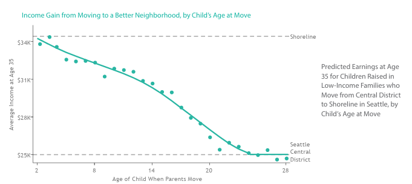

## 계층이동 연구 모듈 2

2024년에 발표된 이들의 후속 연구 (모듈 2)에서는 1978년에 태어난 코호트와 1992년에 태어난 코호트의 세대 간 계층 이동 가능성을 비교한다. 결국 모듈 1이 "현재 어디서 자라는 것이 유리한가"를 보여준다면, 모듈 2는 "어느 지역의 기회가 시간에 따라 확대되거나 축소되고 있는가"를 보여주는 것이다.

이번에는 1978-1992년생이라는 더 넓은 출생 코호트를 대상으로 27세 시점의 성과를 측정하여, 15년간의 변화 추이를 분석한다. 센서스 트랙트 단위의 세밀한 분석은 제외하고 카운티와 통근권역 수준에서만 분석하되, 각 지역과 인구 하위그룹별로 출생 연도에 따른 선형 추세를 계산한다. 예를 들어, 어떤 카운티에서 1978년생 저소득층 아이들의 평균 소득이 3만 5천 달러였는데 1992년생은 3만 달러로 감소했다면, 이 지역의 경제적 이동성이 연간 약 330달러씩 악화되고 있음을 보여준다.

주요 결과는 다음과 같다.

1. 전국적으로 계층이동성이 감소하는 추세이지만, 지역별 격차가 크게 벌어지고 있다. 일부 도시는 개선되고 있는 반면, 많은 농촌 지역과 러스트벨트 지역은 급격히 악화되고 있다.
2. 특히 중서부 농촌 지역의 계층이동성 하락이 두드러진다. 과거 높은 이동성을 보였던 아이오와, 위스콘신 등의 지역에서 젊은 세대의 기회가 현저히 줄어들었다.
3. 대도시 중에서는 시애틀, 덴버, 미니애폴리스 등 기술 산업이 성장한 지역의 계층이동성이 개선되었으나, 디트로이트, 클리블랜드 같은 전통 제조업 도시는 계속 악화되고 있다.
4. 인종별 격차도 변화하고 있다. 일부 지역에서는 흑인과 히스패닉의 계층이동성이 개선되었지만, 백인 저소득층의 이동성은 많은 지역에서 정체되거나 하락했다.
5. 교육 투자를 늘리고 지역 경제를 다각화한 지역일수록 계층이동성이 개선되는 경향을 보였다.

##### 그림 2. 인종별 계층 이동 가능성의 변화 추세

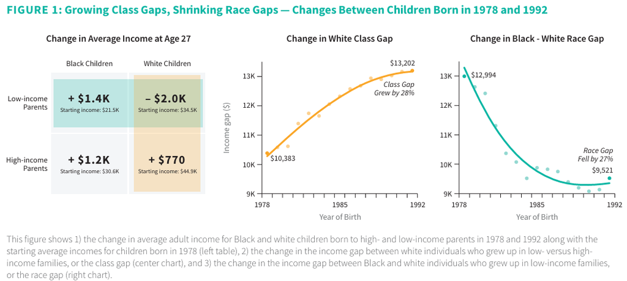

정리하면, 이 프로젝트에서 핵심 중 하나는 이웃효과 혹은 지리적 위치에 따라서 보이는 다양한 패턴일 것이다. 어린 시절 여러 지역에 거주한 경우에는 각 지역에서 보낸 시간에 비례하여 가중치를 부여하는 정교한 방법을 사용했다. 앞선 계층이동 가능성의 하락 요인으로 저자들이 꼽은 제 1요인 역시 인종 및 소득에 따른 지역 분리 (racial and residential segregation)이었다. 앞선 두 프로젝트에서 모두 저자들은 응답자들이 태어났던 지역, 23살까지 살았던 지역 정보를 활용하여 다양한 이웃효과 요인을 고려한다.

##### 그림 3. The Opportunity Atlas 온라인 시각화 일부: https://www.opportunityatlas.org/

[figure not shown]

그리고 나머지 요인으로는 임금 불평등, 가족구조 변화, 마지막으로 사회 자본이다.

## 사회자본 연구 1

이 중에서 사회자본에 대한 연구는 2022년 The Social Capital Atlas라는 이름으로 별도의 프로젝트가 수행되었다. 720만명의 페이스북, 인스타그램 데이터를 활용하여 210억 개가 넘는 친구 관계 연결망을 분석한 방대한 연구다. 이 프로젝트는 크게 두 개의 연구로 구분된다. 두 연구는 각각 "[Social capital I: measurement and associations with economic mobility](https://www.nature.com/articles/s41586-022-04996-4)" 그리고 "[Social capital II: determinants of economic connectedness](https://www.nature.com/articles/s41586-022-04997-3)"라는 이름으로 Nature 저널에 실린다.

첫 번째 연구에서는 세 가지 종류의 사회자본을 측정한다. (1) 경제적 연결성(Economic Connectedness)은 저소득층과 고소득층 간 상호작용 정도를 나타내는데, 저소득층 개인이 가진 고소득층 친구의 비율을 2배로 계산하여 측정한다. 예를 들어, 저소득층의 친구 중 평균 25%가 고소득층이면 경제적 연결성은 0.5가 된다. (2) 결속성(Cohesiveness)은 사회 네트워크가 파벌로 분화되는 정도를 측정하며, 두 가지 지표를 사용한다. 클러스터링은 개인의 친구들끼리도 서로 친구인 비율을 계산하고, 지원 비율은 같은 지역 내에서 두 친구가 공통의 제3자 친구를 가진 비율을 측정한다. (3) 시민 참여(Civic Engagement)는 자원봉사 및 지역사회 조직 참여율을 나타내는데, Facebook에서 자원봉사나 사회운동 관련 그룹에 가입한 사용자 비율과 지역별 공공선 관련 Facebook 페이지 수(인구 1,000명당)로 측정한다.

##### 그림 4. 자신의 임금 구간과 친구의 임금 구간 비율

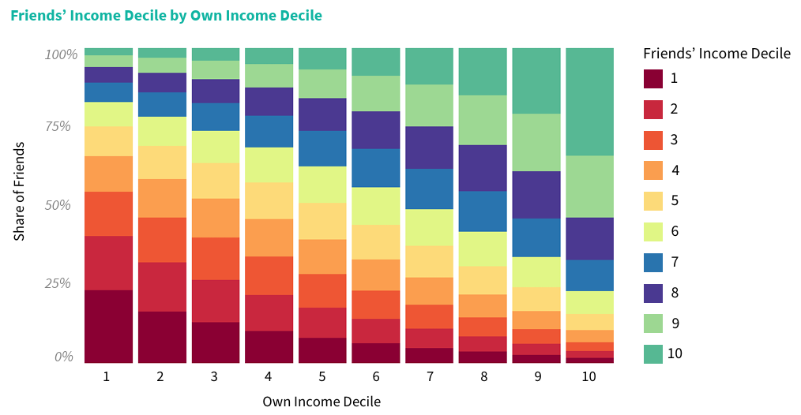

그렇다면 위 세 가지 사회자본 중에서 계층이동에 가장 중요한 것은 무엇일까? 바로 1번, 경제적 연결성이었다. 다시 말해, 저소득 가정 아이들이 고소득층과 더 많이 교류하는 지역에서 자란 경우, 성인이 되어 빈곤에서 탈출할 확률이 훨씬 높았다. 실제로 경제적 연결성이 1 표준편차 증가하면 저소득층 아이들의 미래 소득이 약 20% 상승하는 것으로 나타났다. 이는 부모 소득, 인종 구성, 학교 질 등 다른 요인들을 통제한 후에도 유의미했다. 반면 (2) 지역사회의 결속력이나 (3) 시민 참여도는 계층이동과 강한 연관성을 보이지 않았다.

##### 그림 5. 중위 가구소득과 경제적 연결성, 계층이동성의 관계

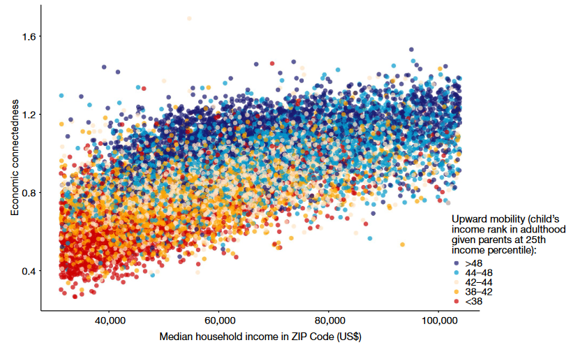

## 사회자본 연구 2

##### 그림 6. 두 번째 연구 결과 요약

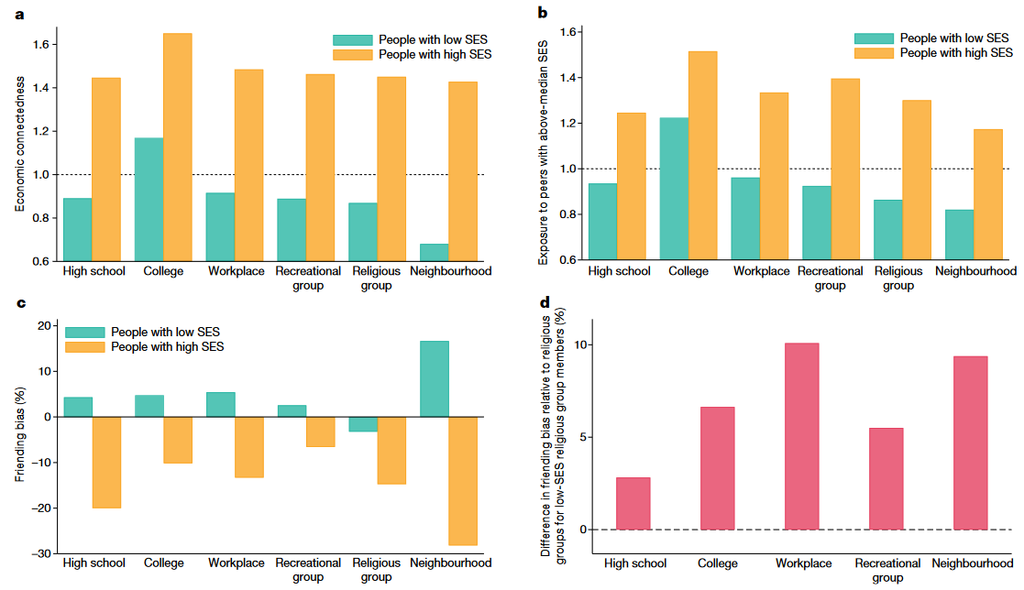